# Practical Machine Learning Assignment

July 2015

# Introduction

The purpose of this assignment is to build a model that accurately predicts the performance of weight lifters performing barbell lifts. The training data consists of measurements of various accelerometers strapped to the lifter: 19,622 observations of 160 variables. The `classe` variable is the target variable for prediction and is a categorical variable taking values from A to E, where A corresponds to a correct lifting technique and D to E correspond to variations of incorrect techniques.

# Data Preparation

```r
library(caret)  # for model building
library(dplyr)  # for sample_frac
library(doMC)  # for multicore processing
library(readr)  # for fast text file reading
library(knitr)  # for kable table formatting
registerDoMC(cores = 3)  # Register both cores for parallel processing
```

```r
# Specify column types in advance (using shorthand readr format)
# (c)haracter, (d)ouble
coltypes <- paste0('ccddccc', paste(rep('d', 152), collapse = ''), 'c')
training <- read_csv('data/pml-training.csv', col_types = coltypes)
```

Although the dataset consists of 160 columns of measurements, many of these columns contain high proportions of missing values. Approximately two thirds of the measurements in the dataset are missing.

The “missingness map” in the figure below illustrates this. The map shows column names on the x-axis and rows on the y-axis, with each cell coloured by its missingness status. The map is constructed on a 10% sample of the dataset for speed.

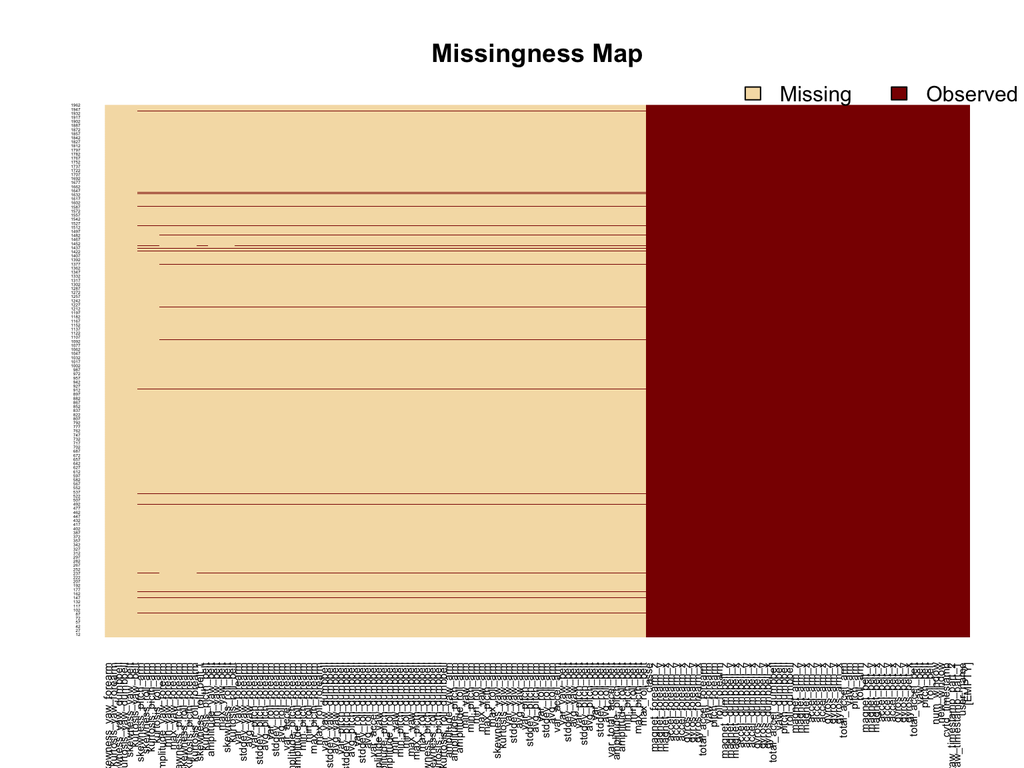

```r
# Plot missingness map and reduce the size of the axis labels
Amelia::missmap(sample_frac(training, size = 0.1),
                y.cex = 0.2, x.cex = 0.5)
```

Although not *every* value is missing from these sparsely-populated columns it seems pragmatic to remove them and focus on the well-populated fields, if only for model-building performance reasons. Therefore these columns were removed from the dataset.

```r
# Remove columns with huge proportion of missing values
# Calculate proportion of missing values in each column
prop_na <- sapply(training, function(x) {sum(is.na(x)) / length(x)})
# Remove columns with more than 90% missing values
to_drop <- names(training) %in% names(prop_na[prop_na > 0.9])
training <- training[, !to_drop]
```

The `classe` column was then converted into a factor with the expectation that the machine learning methods will prefer it.

```r
training$classe <- as.factor(training$class)
```

# Creating Test and Train Datasets

In order to get a more accurate estimate of the predictive accuracy of the final model, the training data was divided into a `train` set and a `test` set. Models were trained on just the `train` dataset, with the hold-out `test` dataset used to assess performance on new data. 70% of the data was allocated to `train` and the remaining 30% allocated to `test`.

```r
# Split data into train and test
in_train <- createDataPartition(y = training$classe, p = 0.7, list = FALSE)
train <- training[in_train, ]
test <- training[-in_train, ]
```

# Model Building

Although several models were tried, the random forest algorithm did a very good job of classifying the `classe` variable from the measurement variables, and this is the model detailed below.

Principal component analysis was tried in order to reduce the number of variables, but the resultant models produced less-accurate results, so the technique was not used in the final model.

```r
# Train a random forest classifier using just the measurement columns (8:59)
rf1 <- train(train$classe ~.,
             method = 'rf',
             data = train[, 8:59])
```

# Assessing Model Accuracy

Cross validation was used to assess the model accuracy, by testing the accuracy of the model on the hold-out `test` dataset, rather than the data used to train the model.

```r
# Print confusion matrix of predictions on the test dataset
cm1 <- confusionMatrix(test$classe, predict(rf1, test))
kable(cm1$table)
```

|  | A | B | C | D | E |
| --- | --- | --- | --- | --- | --- |
| A | 1673 | 1 | 0 | 0 | 0 |
| B | 8 | 1129 | 2 | 0 | 0 |
| C | 0 | 6 | 1017 | 3 | 0 |
| D | 0 | 1 | 11 | 952 | 0 |
| E | 0 | 1 | 0 | 0 | 1081 |

An estimate of the model accuracy based on the hold-out set is 0.994:

```r
accuracy <- cm1$overall[['Accuracy']]
accuracy
```

```
## [1] 0.9943925
```

Or in other words, the out-of-sample error rate is estimated to be `1 - accuracy`, i.e. 0.006.